# ML Algorithms for classification

Slides – http://bit.ly/2q9NPSU

## Aims of this lesson

- Give you a general introduction to neural networks, How they works and how to implement them in `R`.

## What are Neural networks

https://www.youtube.com/watch?v=bxe2T-V8XRs

https://www.youtube.com/watch?v=UJwK6jAStmg

https://www.youtube.com/watch?v=5u0jaA3qAGk&t=45s

https://www.youtube.com/watch?v=GlcnxUlrtek

https://www.youtube.com/watch?v=pHMzNW8Agq4

https://www.youtube.com/watch?v=9KM9Td6RVgQ

https://www.youtube.com/watch?v=S4ZUwgesjS8

## Neural network from scratch

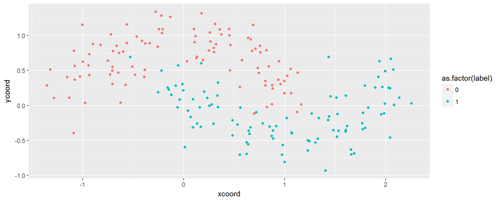

## Neural network from scratch

- Our goal is to train a Machine Learning classifier that predicts the correct class (male of female) given the x- and y- coordinates.
- Data is not linearly separable, we can't draw a straight line that separates the two classes.
- This means that linear classifiers, such as Logistic Regression, won't be able to fit the data unless you hand-engineer non-linear features (such as polynomials) that work well for the given dataset.
- That's one of the major advantages of Neural Networks. You don't need to worry about feature engineering. The hidden layer of a neural network will learn features for you.

## Fitting the logistic regression

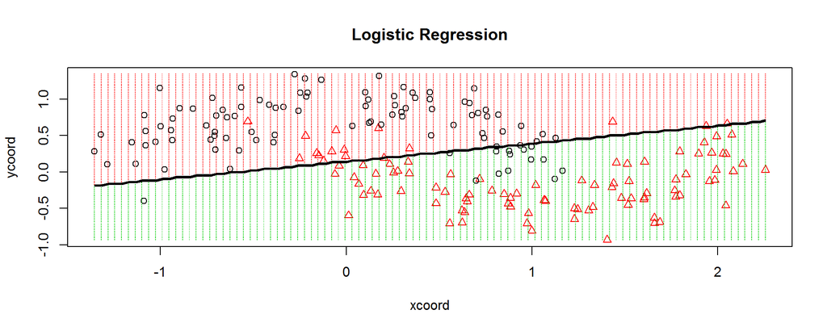

- The graph shows the decision boundary learned by our Logistic Regression classifier.
- It separates the data as good as it can using a straight line, but it's unable to capture the "moon shape" of our data.

## Training a neural network

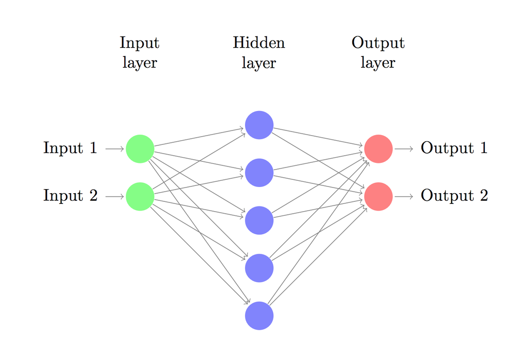

## Training a neural network

We also need to pick an activation function for our hidden layer. activation function transforms the inputs of the layer into its outputs.

- nonlinear activation function is what allows us to fit nonlinear hypotheses.
- common chocies for activation functions are [tanh](https://reference.wolfram.com/language/ref/Tanh.html), the [sigmoid](https://en.wikipedia.org/wiki/Sigmoid_function) function, or ReLUs
- Because we want our network to output probabilities the activation function for the output layer will be the [softmax](https://en.wikipedia.org/wiki/Softmax_function)

## How our network makes predictions

- Our network makes predictions using forward propagation (bunch of matrix multiplications and the application of the activation functions

\[ z_1 = x.W_1 + b_1\\ a_1 = \tanh(z_1)\\ z_2 = a_1.W_2 + b_2\\ a_2 = \hat{y} = \text{softmax}(z_2) \]

- \(z_i\) is the input of layer \(i\) and \(a_i\) is the output of layer \(i\) after applying the activation function.
- \(W_1, b_1, W_2, b_2\) are parameters of our network, which we need to learn from our training data.

If we use 500 nodes for the hidden layer then \(W_1 \in \mathbb{R}^{2\times500}\), \(b_1 \in \mathbb{R}^{500}\), \(W_2 \in \mathbb{R}^{500\times2}\) and \(b_2 \in \mathbb{R}^{2}\)

## Learning the parameters

- Learning the parameters for our network means finding parameters \((W_1, b_1, W_2, b_2)\) that minimize the error on our training data
- We call the function that measures our error the loss function.
- A common choice with the softmax output is the categorical [cross-entropy loss](http://bit.ly/2pm9KbO) (also known as negative log likelihood)
- If we have \(N\) training examples and \(C\) classes then the loss for our prediction \(\hat{y}\) with respect to the true labels \(y\) is given by:

\[L(y,\hat{y}) = -\frac{1}{N }\sum_{n\in N}\Big( y_{n}\log\hat{y_{n}} + (1-y_{n}) \log(1-\hat{y_n})\Big)\]

- The formula looks complicated, but all it really does is sum over our training examples and add to the loss if we predicted the incorrect class.
- We can use gradient descent to find the minimum and I will implement the most vanilla version of gradient descent, also called batch gradient descent with a fixed learning rate.

## Learning the parameters

- Variations such as SGD (stochastic gradient descent) or minibatch gradient descent typically perform better in practice. So if you are serious you'll want to use one of these.
- As an input, gradient descent needs the gradients (vector of derivatives) of the loss function with respect to our parameter \(\frac{\partial{L}}{\partial{W_1}}\), \(\frac{\partial{L}}{\partial{b_1}}\), \(\frac{\partial{L}}{\partial{W_2}}\), \(\frac{\partial{L}}{\partial{b_2}}\).
- To calculate these gradients we use the famous backpropagation algorithm, which is a way to efficiently calculate the gradients starting from the output.

I won't go into detail how backpropagation works, but there are many excellent explanations ([here](http://colah.github.io/posts/2015-08-Backprop/) or here) floating around the web.

## Learning the parameters

Applying the backpropagation formula we find the following (trust me on this):

\(\delta_3 = \hat{y} - y\)

\(\delta_2 = (1 - \tanh^2 z_1) \circ \delta_3W_2^T\)

\(\frac{\partial{L}}{\partial{W_2}} = a_1^T \delta_3\)

\(\frac{\partial{L}}{\partial{b_2}} = \delta_3\)

\(\frac{\partial{L}}{\partial{W_1}} = x^T \delta2\)

\(\frac{\partial{L}}{\partial{b_1}} = \delta2\)

## Implementation

We start by defining some useful variables and parameters for gradient descent:

```r
num_examples = nrow(moons)

nn_input_dim = 2 # input layer dimensionality
nn_output_dim = 2 # output layer dimensionality
 # Gradient descent parameters (I picked these by hand)

epsilon = 0.01 # learning rate for gradient descent
reg_lambda = 0.01 # regularization strength
```

First let's implement the loss function we defined above. We use this to evaluate how well our model is doing:

```r
##################################################################################
# Project:      Neural networks from scratch
# Description:  Calculate Loss function
# Data:         moons data set
# By:           Hicham Zmarrou
# url:          www.trefoil.ml
##################################################################################

# Helper function to evaluate the total loss on the dataset
# Helper function to evaluate the total loss on the dataset


calculate_nn_loss <- function(model){

  # load the model parameters
  #X  = X ; y =y
  W1 = model$W1
  b1 = model$b1
  W2 = model$W2
  b2 = model$b2
  # Forward propagation to calculate our predictions
  z1         = X%*%W1 + b1
  a1         = tanh(z1)
  z2         = a1%*%W2 + b2
  exp_scores = exp(z2)
  probs      = exp_scores/rowSums(exp_scores)
  probsXum   = rowSums(probs * cbind( (1-y),y))
  # Calculating the loss

  corect_logprobs = -log(probsXum)
  data_loss       =  sum(corect_logprobs)

  # Add regulatization term to loss (optional)

  data_loss  =   data_loss + reg_lambda/2 * (sum(W1^2) + sum(W2^2))
  return (1/ num_examples * data_loss)
}
```

We also implement a helper function to calculate the output of the network. It does forward propagation as defined above and returns the class with the highest probability.

```r
##################################################################################
# Project:      Neural networks from scratch
# Description:  Helper function to predict an output (0 or 1)
# Data:         moons data set
# By:           Hicham Zmarrou
# url:          www.trefoil.ml
##################################################################################

# We also implement a helper function to calculate the output of the network.
# It does forward propagation as defined above and returns the class with the highest probability.


predict_nn <- function(model, X){

  # load the model parameters

  W1 = model$W1
  b1 = model$b1
  W2 = model$W2
  b2 = model$b2

  # Forward propagation to calculate our predictions
  z1         = X%*%W1 + b1
  a1         = tanh(z1)
  z2         = a1%*%W2 + b2
  exp_scores = exp(z2)

  probs      = exp_scores/rowSums(exp_scores)
  apply(probs, 1, which.max) - 1
  return (apply(probs, 1, which.max) - 1)
}
```

Finally, here comes the function to train our Neural Network. It implements batch gradient descent using the backpropagation derivates we found above.

```r
# This function learns parameters for the neural network and returns the model.
# - nn_hdim: Number of nodes in the hidden layer
# - num_passes: Number of passes through the training data for gradient descent
# - print_loss: If True, print the loss every 1000 iterations
build_nn_model <- function(nn_hdim = 3,num_passes=20000,X,Y,print_loss = F){

  nn_hdim = 3 ; print_loss = TRUE
  X = as.matrix(moons[,1:2])
  y = as.matrix(moons[,3])
  set.seed(1)

  W1 <- read_delim("./data/W1.txt","\t", escape_double = FALSE, col_names = FALSE, trim_ws = TRUE)
  W1 <- as.matrix(W1)
  #W1  = matrix(rnorm(nn_input_dim*nn_hdim),nn_input_dim, nn_hdim)/sqrt(nn_input_dim)
  b1  = numeric(nn_hdim)

  ###########
  W2 <- read_delim("./data/W2.txt", "\t", escape_double = FALSE, col_names = FALSE, trim_ws = TRUE)
  W2 <- as.matrix(W2)
  #W2  = matrix(rnorm(nn_hdim*nn_output_dim),nn_hdim,nn_input_dim)/sqrt(nn_hdim)
  b2  = numeric(nn_output_dim)

  num_passes = 20

  model <- list() # This is what we return at the end

  for (i in 1:num_passes){

    z1 =  X%*%W1 + b1
    a1 =  tanh(z1)
    z2 =  a1%*%W2 + b2
    exp_scores = exp(z2)
    probs = (exp_scores / rowSums(exp_scores))

    # Backpropagation
    delta3 =  probs
    delta3 =  delta3 - matrix(c(1-y,y),200,2)
    # delta3[range(num_examples), y] -= 1
    dW2 = t(a1) %*% delta3
    #dW2 = (a1.T).dot(delta3)
    db2 = colSums(delta3)

    delta2 = delta3 %*% t(W2) * (1 - (a1^2))
    dW1 = t(X) %*%  delta2
    db1 = colSums(delta2)

    # Add regularization terms (b1 and b2 don't have regularization terms)
    dW2 <-  dW2 + reg_lambda*W2
    dW1 <-  dW1 + reg_lambda*W1

    # Gradient descent parameter update
    W1 <- W1 - epsilon * dW1
    b1 <- b1 - epsilon * db1
    W2 <- W2 - epsilon * dW2
    b2 <- b2 - epsilon * db2

    model$W1 =  W1
    model$b1 =  b1
    model$W2 =  W2
    model$b2 =  b2

    # Optionally print the loss.
    # # This is expensive because it uses the whole dataset, so we don't want to do it too often.

    if ((print_loss == TRUE)  & (i %% 1000 == 0)) {
      print(paste("Loss after iteration", i , ": " , calculate_nn_loss(model)))
    }

  }
  # Optionally print the loss.
  # # This is expensive because it uses the whole dataset, so we don't want to do it too often.
  return(model)
}
```

## A network with a hidden layer of size 3

```r
x <-  moons[1:150, c("xcoord", "ycoord", "label")]
x$label <- as.factor(x$label)
levels(x$label) <- c("m","f")
head(x)
```

```
#>       xcoord     ycoord label
#> 1  0.7434612  0.4646563     m
#> 2  1.6575566 -0.6320316     f
#> 3 -0.1587887  0.2558446     f
#> 4 -1.0887520 -0.3969432     m
#> 5  1.7680520 -0.2544321     f
#> 6  1.9541645 -0.1285058     f
```

```r
library(nnet)
model <- nnet(label ~ ., data=x, size =3, maxit = 1000, trace = FALSE)
```

## A network with a hidden layer of size 3

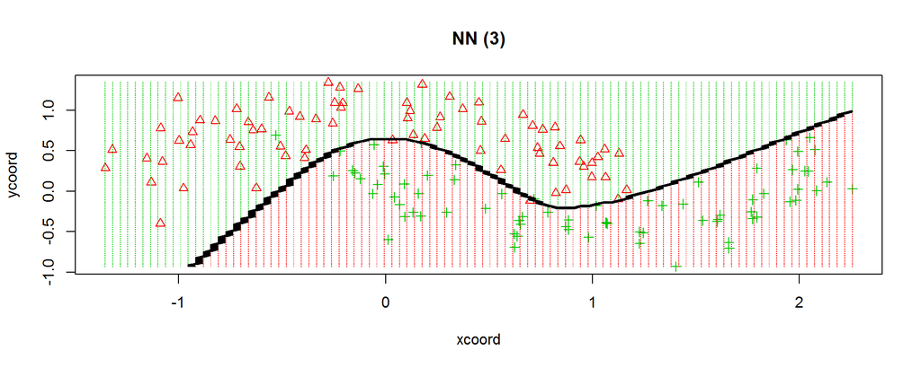

```r
myplot(model, x, class = "label", main = "NN (3)")
```

## Circle dataset

```r
set.seed(1000)

library(mlbench)
x <- mlbench.circle(100)
#x <- mlbench.cassini(100)
#x <- mlbench.spirals(100, sd = .1)
#x <- mlbench.smiley(100)
x <- cbind(as.data.frame(x$x), factor(x$classes))
colnames(x) <- c("x", "y", "class")

head(x)
```

```
#>             x           y class
#> 1 -0.34424258  0.19873584     1
#> 2  0.51769297 -0.09663637     1
#> 3 -0.77212721 -0.72634916     2
#> 4  0.38151030  0.45235760     1
#> 5  0.03280481  0.30910652     1
#> 6 -0.86452408  0.69246504     2
```

## Circle dataset (Logistic Regression)

Logistic Regression Only considers for 2 classes

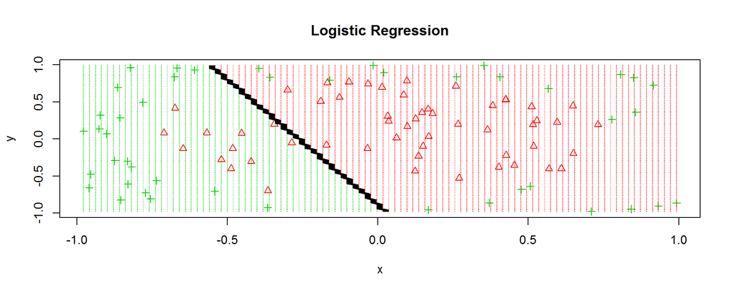

```r
model <- glm(class ~., data = x, family=binomial(link='logit'))
class(model) <- c("lr", class(model))
predict.lr <- function(object, newdata, ...)
  predict.glm(object, newdata, type = "response") > .5

myplot(model, x, class = "class", main = "Logistic Regression")
```

## Circle dataset (Decision trees)

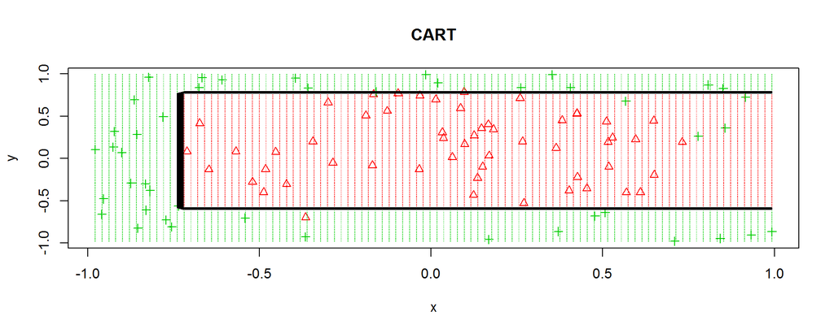

```r
library("rpart")
model <- rpart(class ~ ., data=x)
myplot(model, x, class = "class", main = "CART")
```

## Circle dataset (Decision trees overfitting)

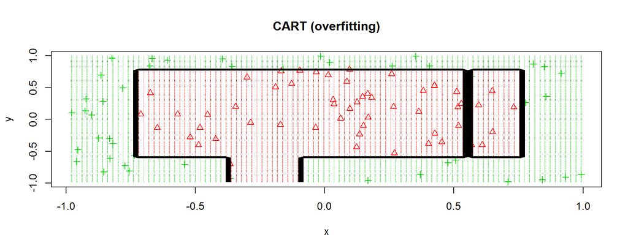

```r
model <- rpart(class ~ ., data=x,
  control = rpart.control(cp = 0.001, minsplit = 1))
myplot(model, x, class = "class", main = "CART (overfitting)")
```

## Circle dataset (Decision trees C5.0)

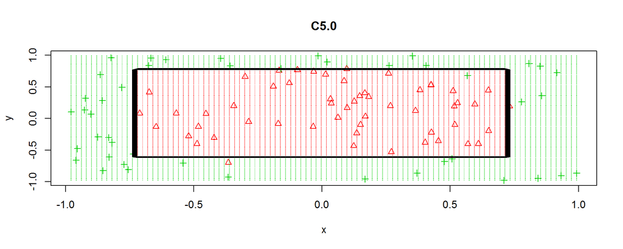

```r
library(C50)
model <- C5.0(class ~ ., data=x)
myplot(model, x, class = "class", main = "C5.0")
```

## Circle dataset (Random Forest)

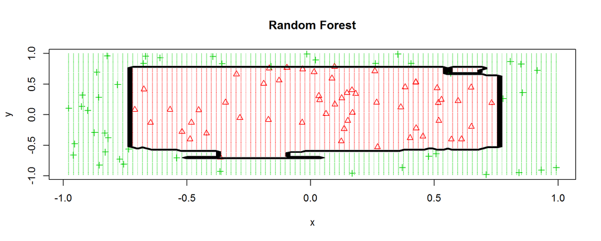

```r
library(randomForest)
model <- randomForest(class ~ ., data=x)
myplot(model, x, class = "class", main = "Random Forest")
```

## Circle dataset (Neural Network)

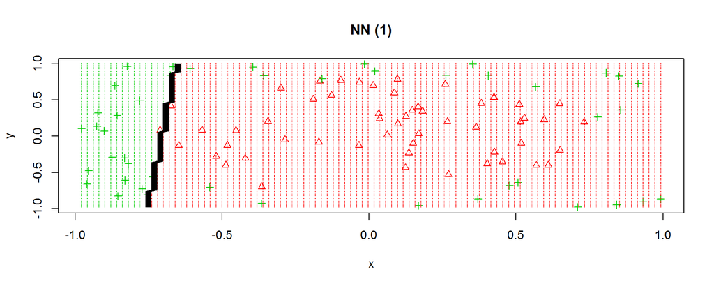

```r
library(nnet)
model <- nnet(class ~ ., data=x, size = 1, maxit = 1000, trace = FALSE)
myplot(model, x, class = "class", main = "NN (1)")
```

## Circle dataset (Neural Network)

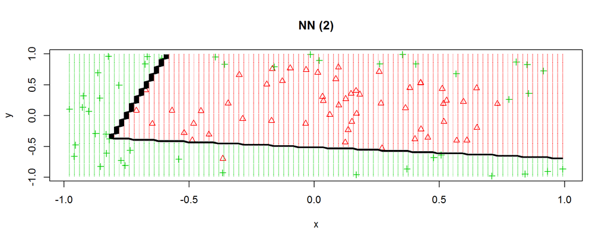

```r
library(nnet)
model <- nnet(class ~ ., data=x, size = 2, maxit = 1000, trace = FALSE)
myplot(model, x, class = "class", main = "NN (2)")
```

## Circle dataset (Neural Network)

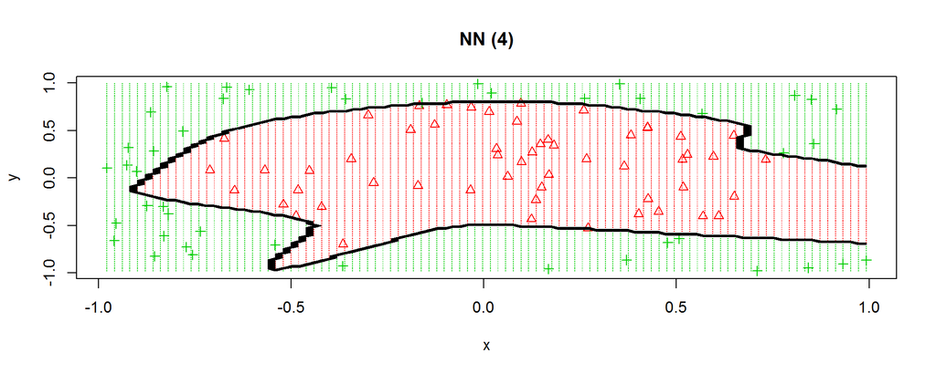

```r
library(nnet)
model <- nnet(class ~ ., data=x, size = 4, maxit = 1000, trace = FALSE)
myplot(model, x, class = "class", main = "NN (4)")
```

## Circle dataset (Neural Network)

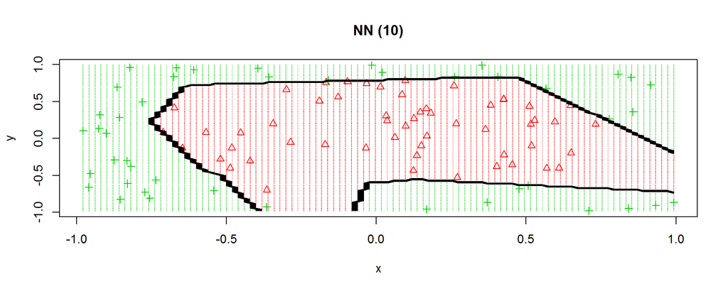

```r
library(nnet)
model <- nnet(class ~ ., data=x, size = 10, maxit = 1000, trace = FALSE)
myplot(model, x, class = "class", main = "NN (10)")
```